## 4th Markdown Assignment

## Group 1 (Agbayani, Cu, Dizon, Pagcatipunan)

### Intro

As households in developing countries become more financially stable, the household will transition to more upscale sources of energy (energy ladder concept). The following multiple linear regression model will test this concept by measuring the relationship between where the household are located with the source of their power or electricity.

### Methodology

#### Information about the origin of data

The data was collected from two provinces of Cambodia. These provinces are the province of Pursat and the province of Kampong Chan. Pursat is located in western Cambodia and is filled with forests, local wildlife sanctuaries, fertile food plains and a lake with fisheries. Kampong Chan is located in central Cambodia and is mostly agricultural lowlands with a small forest to the north. This province has a higher population and is wealthier than Pursat.

#### How the data was taken

A multistage sampling was used to collect the data. The determinants were province, level of urbanization and access to electricity. Province refers to which province the household comes from and if they belong from either the upper class, middle class or lower class. Level of urbanization refers to the fact if the household is in a rural or urban community. Access to electricity refers if the household uses batteries or they are connected to the electrical grid. 970 households were used for the entire research. 875 households were labelled as rural and 95 for urban. From these urban and rural households, 309 were lower class, 405 were middle class and 256 were higher class. Out of the 970 households, 669 households were electrified and connected to the electrical grid and 301 were not. If the household was earning less than 5,000 USD per month, they are considered low class. If between 5,500 and 18,000 USD, they are considered middle class. The household is considered upperclass if they earn more than 18,00 USD. Interviews were conducted within the two provinces in late 2015. 78 villages were a part of these interviews. The interviewers asked questions about socioeconomic characteristics of their households, livelihood strategies, energy usage, access to the natural resources and if there were changes they saw within their community

Here is the data that was collected in a form of a graph

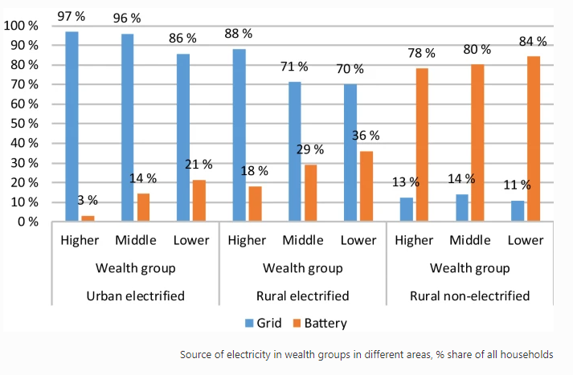

Graphed data

### Results

```
##                   Place Wealth.Group Grid Battery
## 1                 Urban       Higher   97       3
## 2                             Middle   96      14
## 3                              Lower   86      21
## 4     Rural electrified       Higher   88      18
## 5                             Middle   71      29
## 6                              Lower   70      36
## 7 Rural non-electrified       Higher   13      78
## 8                             Middle   14      80
## 9                              Lower   11      84
```

Urban = 3, Rural electrified = 2, Rural non-electrified = 1

#### Place

```
##
## Call:
## lm(formula = Data$Place ~ Data$Battery + Data$Grid)
##
## Residuals:
##      Min       1Q   Median       3Q      Max
## -0.59352 -0.19572  0.03234  0.19492  0.45279
##
## Coefficients:
##              Estimate Std. Error t value Pr(>|t|)
## (Intercept)   0.87240    3.41970   0.255    0.807
## Data$Battery -0.00211    0.03723  -0.057    0.957
## Data$Grid     0.01999    0.03166   0.631    0.551
##
## Residual standard error: 0.354 on 6 degrees of freedom
## Multiple R-squared:  0.8747, Adjusted R-squared:  0.8329
## F-statistic: 20.94 on 2 and 6 DF,  p-value: 0.001968
```

```
## Analysis of Variance Table
##
## Response: Data$Place
##              Df Sum Sq Mean Sq F value    Pr(>F)
## Data$Battery  1 5.1981  5.1981 41.4772 0.0006631 ***
## Data$Grid     1 0.0500  0.0500  0.3986 0.5511001
## Residuals     6 0.7519  0.1253
## ---
## Signif. codes:  0 '***' 0.001 '**' 0.01 '*' 0.05 '.' 0.1 ' ' 1
```

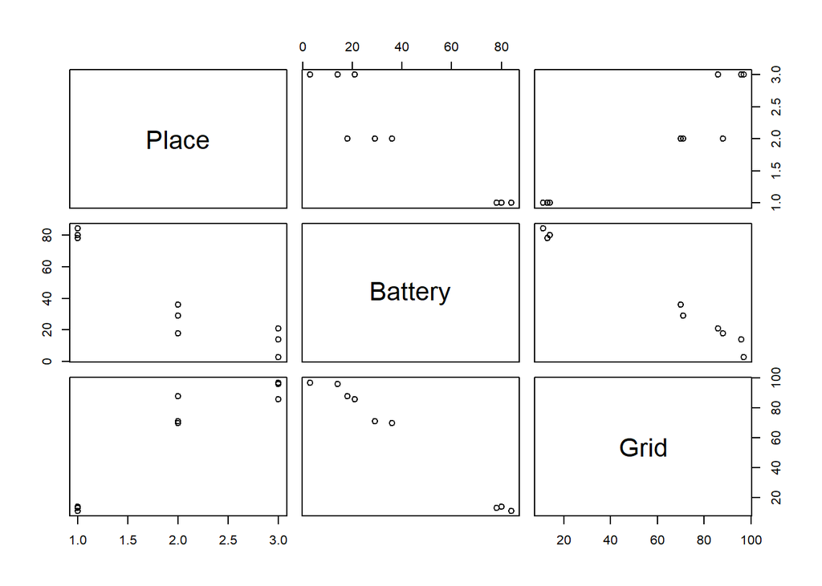

Testing for the significance of the regression with
$$H_0: \beta_1 = \beta_1 = 0$$
$$H_1: \beta_1 or \beta_2 or \beta_3 \neq 0$$
$$F_0 = \frac{SS_R/k}{SS_E/(n-p)}=\frac{MS_R}{MS_E}$$

$F_0 = 20.94214$

$f_{0.05,2,6} = 5.1433$

$20.94214 > 5.1433$

We reject $H_o$, There is a significant relationship to place, battery, and grid but further testing is required to know if both battery and grid has the same conclusion.

We can test for each individual regression coefficient to see each significance using:

$$H_0: \beta_j = \beta_{j0}$$
$$H_1: \beta_j \neq \beta_{j0}$$

$$T_0 = \frac{\hat{\beta_j}-\beta_{j0}}{\sqrt{\sigma^{2}C_{jj}}}$$

$$C_{jj} = (X'X)^{-1}$$

#### C =

```
##
## [1,] 93.3123791 -1.01343048 -0.86252042
## [2,] -1.0134305  0.01105906  0.00935244
## [3,] -0.8625204  0.00935244  0.00799954
```

For $\beta_1$ when $\beta_2 = 0$, $T_0 = -0.05668235$

$|t_0| = 0.05668235 < t_{0.025,6} = 2.447$

$P(t_0) = 0.956702 > \alpha = 0.05$

We fail to reject $H_0$ for Battery usage

For $\beta_2$ when $\beta_1 = 0$, $T_0 = 0.6314003$

$|t_0| = 0.6314003 < t_{0.025,6} = 2.447$

$P(t_0) = 0.55106 > \alpha = 0.05$

We fail to reject $H_0$ for Grid usage

### Discussions and Conclusion

The primary concern is to see if there is a relationship with the place where they are staying by looking at what type of electricity are they using whether it is using the grid or battery.

The results gathered from the study, through investigation, states that there is a significant relationship to the place where the household is to the source of their electricity. This can be seen in the first test which rejected the null hypothesis. On the other hand, the second test showed a different result with both battery and grid failing to reject the null hypothesis.

### Source

Mika, K., Minna, M., Noora, V., Jyrki, L., Jari, K.-oja, Anna, A., Eliyan, C., Dany, V., Maarit, K., & Nicholas, H. (2021). Situation analysis of energy use and consumption in CAMBODIA: HOUSEHOLD access to energy. Environment, Development and Sustainability. https://doi.org/10.1007/s10668-021-01443-8